# Assignment4

Tejaswini Sengaonkar

2023-10-16

## Assignment 4

```r
UPI.last <- 7
set.seed(UPI.last)

rw2d5b <- function(n, start = c(0, 0), prob = rep(0.25, 4)) {
  xsteps <- c(-1, 1, 0, 0)
  ysteps <- c(0, 0, -1, 1)

  dir <- sample(1:4, n - 1, replace = TRUE, prob = prob)
  x <- c(start[1], cumsum(xsteps[dir]))
  y <- c(start[2], cumsum(ysteps[dir]))

  list(x = x, y = y, path = cbind(x, y), probabilities = prob)
}
```

2. Obtain an object called walkl that starts at (3, 5) and takes 100 steps and having prob= c(0, 1/3, 1/3, 1/3), i.e., it never goes to the left. Note: let step 1 be the initial position.

```r
walk1 <- rw2d5b(100, start = c(3, 5), prob = c(0, 1/3, 1/3, 1/3))
walk1
```

```
## $x
##   [1]  3  0  0  1  2  3  3  3  3  4  4  5  6  6  7  7  8  8  9  9 10 10 11 11 11
##  [26] 11 12 12 12 12 12 12 13 14 15 15 15 15 15 15 15 15 15 15 15 15 16 17 17 17
##  [51] 17 17 17 17 17 17 17 18 19 19 20 21 21 21 21 21 21 21 21 21 21 22 22 22 22
##  [76] 23 23 23 23 23 23 23 23 24 24 24 25 26 26 26 26 26 27 27 28 28 28 28 28 28
##
## $y
##   [1]  5  1  0  0  0  0  1  0  1  1  0  0  0  1  1  0  0 -1 -1  0  0 -1 -1  0  1
##  [26]  2  2  1  0  1  0  1  1  1  1  0  1  0  1  2  1  2  1  2  1  2  2  2  3  4
##  [51]  5  4  5  6  5  6  5  5  5  4  4  4  3  4  5  4  3  2  1  0 -1 -1 -2 -1 -2
##  [76] -2 -3 -4 -5 -6 -5 -4 -3 -3 -2 -3 -3 -3 -2 -3 -4 -5 -5 -4 -4 -3 -4 -5 -6 -5
##
## $path
##         x  y
##   [1,]  3  5
```

[output cut: 102 more lines]

3. Write a constructor function that has as input the output of rw2d5b(). It coerces the random walk into an S4 object. In particular, the coordinates should be stored as a two- column matrix. The four probabilities should also be part of the object. Call your object walk4.

```r
setClass("walk4",
         representation(
           path = "matrix",
           probabilities = "numeric"
         )
)

create_walk4 <- function(output) {
  walk4_obj <- new("walk4",
                   path = cbind(output$x, output$y),
                   probabilities = output$prob)
  return(walk4_obj)
}

walk4 <- create_walk4(walk1)
walk4
```

```
## An object of class "walk4"
## Slot "path":
##        [,1] [,2]
##   [1,]    3    5
##   [2,]    0    1
##   [3,]    0    0
##   [4,]    1    0
##   [5,]    2    0
##   [6,]    3    0
##   [7,]    3    1
##   [8,]    3    0
##   [9,]    3    1
##  [10,]    4    1
##  [11,]    4    0
##  [12,]    5    0
```

[output cut: 91 more lines]

4. Continuing on, we want length(walk4) to return how many steps a random walk called walk4 made. Since walk4 has a matrix slot, does length() inherit from the matrix slot— yes or no? If yes, very briefly explain why. If not, write a method so that length(walk4) will work.

```r
setMethod("length", "walk4", function(x) nrow(x@path))
length(walk4)
```

```
## [1] 100
```

No, the length() function in R does not inherently inherit from the matrix slot of an S4 object. The length() function is primarily designed for atomic vectors and does not automatically apply to more complex S4 objects.

5. Continuing on, create a new generic function and then a method which returns how many times the random walk crossed the same position, e.g., if the path were (0, 0), (1, 0), (1, 1), (1, 0), (1, 1), (1, 0), (2, 0), (3, 0), then it would return the value 3. That is, returning to a location multiple times counts more than once. Run it on walk4.

```r
count_crossings <- function(walk) {
  UseMethod("count_crossings")
}

# method
setMethod("count_crossings", "walk4", function(walk) {
  path <- walk@path
  unique_positions <- unique(path)
  crossings <- sum(duplicated(path) | duplicated(path, fromLast = TRUE))
  return(crossings)
})

# Example
set.seed(UPI.last)
output <- rw2d5b(100, start = c(3, 5), prob = c(0, 1/3, 1/3, 1/3))
walk4 <- create_walk4(output)

count_crossings(walk4)
```

```
## [1] 52
```

6. Write/create a new S4 generic function to plot the random walk path.

```r
setGeneric("display", function(object, ...) {
  standardGeneric("display")
})
```

```
## [1] "display"
```

```r
setGeneric("display")
```

```
## [1] "display"
```

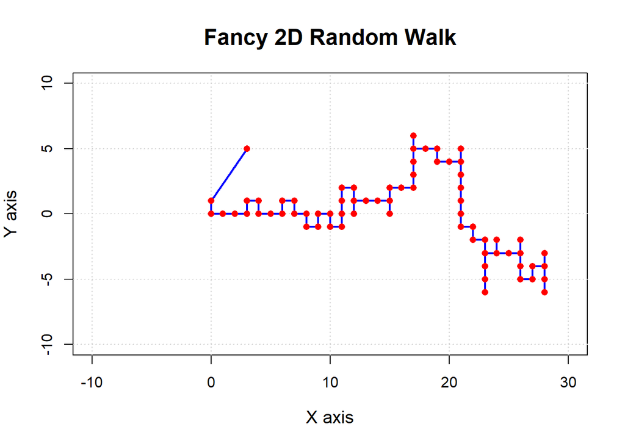

```r
setMethod("display", "walk4", function(object, col = "blue", lwd = 2, pch = 16, main = "2D Random Walk", heading = NULL, ...) {

  plot(object@path[, 1], object@path[, 2], type = "n", xlab = "X axis", ylab = "Y axis", xlim = c(-10, 30), ylim = c(-10, 10), main = "Fancy 2D Random Walk",
       col = "darkgreen",pch = 18,cex.main = 1.5,cex.lab = 1.2)

  grid(col = "lightgray", lty = "dotted")

  lines(object@path[, 1], object@path[, 2], col = col, lwd = lwd)

  points(object@path[, 1], object@path[, 2], col = "red", pch = pch)

})

# Example
display(walk4)
```

7. Write an S3 generic function to return the (Euclidean) distance of a random walk, i.e., from start to finish. Run it on walk3, where walk3 is the output from an S3 constructor function that you should write.

```r
create_walk3 <- function(n, start = c(0, 0), prob = c(0.25, 0.25, 0.25, 0.25)) {
  xsteps <- c(-1, 1, 0, 0)
  ysteps <- c(0, 0, -1, 1)
  dir <- sample(1:4, n - 1, replace = TRUE)
  x <- c(start[1], cumsum(xsteps[dir]))
  y <- c(start[2], cumsum(ysteps[dir]))
  path <- data.frame(x = x, y = y)
  walk3 <- list(path = path, probabilities = prob)
  class(walk3) <- "walk3"
  return(walk3)
}

calculate_distance <- function(walk) {
  UseMethod("calculate_distance")
}

calculate_distance.walk3 <- function(walk) {
  path <- walk$path
  start <- path[1, ]
  finish <- path[nrow(path), ]
  euclidean_distance <- sqrt(sum((finish - start)^2))
  return(euclidean_distance)
}

# Example
walk3 <- create_walk3(50)
distance <- calculate_distance(walk3)
print(distance)
```

```
## [1] 8.062258
```

8. Is it a good idea to have S3 and S4 functions to manipulate and examine random walks as defined in (a)? Why or why not?

If the random walk manipulations are relatively simple, involve basic data structures, and you prioritize flexibility and ease of use, S3 methods might be sufficient.If we need more structure, encapsulation, and want to enforce a specific class structure for random walks, S4 methods could be a better choice. S3 is used for simplicity and flexibility in less complex scenarios, and S4 is reserved for situations where you need more formality and control.